# Homelessness Housing Capacity in the U.S. (2024)

India Flores

December 2024

```r
knitr::opts_chunk$set(echo = TRUE, warning = FALSE, message = FALSE)
library(tidyverse)
```

```r
library(readxl)
library(ggplot2)
```

# Introduction

This project analyzes homelessness housing capacity across U.S. states using the 2024 HUD Housing Inventory Count (HIC) dataset. The goal is to understand how housing resources are distributed geographically and across housing types, and how well they meet the actual homeless population needs reported in the Point-in-Time (PIT) count.

# Load HIC 2024

```r
hic_raw <- read_excel(
"C:/Users/indyd/Downloads/2007-2024-HIC-Counts-by-State (2).xlsx",
sheet = "2024",
col_names = FALSE
)

hic_2024 <- hic_raw %>%
select(
state = ...1,
total_beds = ...2,
emergency_shelter = ...15,
transitional_housing = ...27,
permanent_supportive_housing = ...57
) %>%
filter(!is.na(state)) %>%
mutate(
year = 2024,
total_beds = as.numeric(total_beds),
emergency_shelter = as.numeric(emergency_shelter),
transitional_housing = as.numeric(transitional_housing),
permanent_supportive_housing = as.numeric(permanent_supportive_housing)
)

# Load PIT 2024

pit_raw <- read_excel(
"C:/Users/indyd/Downloads/2007-2024-PIT-Counts-by-State (2).xlsx",
sheet = "2024",
col_names = FALSE
)

pit_2024 <- pit_raw %>%
select(
state = ...1,
total_homeless = ...2,
sheltered = ...6,
unsheltered = ...8
) %>%
filter(!is.na(state)) %>%
mutate(
year = 2024,
total_homeless = as.numeric(total_homeless),
sheltered = as.numeric(sheltered),
unsheltered = as.numeric(unsheltered)
)

# Join HIC + PIT to evaluate capacity vs need

hic_pit_2024 <- hic_2024 %>%
inner_join(pit_2024, by = c("state", "year")) %>%
mutate(beds_per_person = total_beds / total_homeless)
```

# Data Overview

```r
# HIC overview

glimpse(hic_2024)
```

```
## Rows: 57
## Columns: 6
## $ state                        <chr> "State", "AK", "AL", "AR", "AZ", "CA", "C…
## $ total_beds                   <dbl> NA, 2039, 2205, 2036, 8884, 75938, 11392,…
## $ emergency_shelter            <dbl> NA, 1438, 1701, 1579, 6967, 61387, 8215, …
## $ transitional_housing         <dbl> NA, 601, 494, 457, 1831, 14078, 3114, 422…
## $ permanent_supportive_housing <dbl> NA, 1132, 2218, 594, 9360, 78758, 7257, 7…
## $ year                         <dbl> 2024, 2024, 2024, 2024, 2024, 2024, 2024,…
```

```r
summary(hic_2024)
```

```
##     state             total_beds     emergency_shelter transitional_housing
##  Length:57          Min.   :    92   Min.   :    30    Min.   :    4
##  Class :character   1st Qu.:  2138   1st Qu.:  1588    1st Qu.:  486
##  Mode  :character   Median :  3656   Median :  2844    Median :  814
##                     Mean   : 18535   Mean   : 15344    Mean   : 3109
##                     3rd Qu.:  8898   3rd Qu.:  6838    3rd Qu.: 1933
##                     Max.   :509710   Max.   :421973    Max.   :85485
##                     NA's   :2        NA's   :2         NA's   :2
##  permanent_supportive_housing      year
##  Min.   :    22               Min.   :2024
##  1st Qu.:  1180               1st Qu.:2024
##  Median :  3805               Median :2024
##  Mean   : 14445               Mean   :2024
##  3rd Qu.:  8364               3rd Qu.:2024
##  Max.   :397241               Max.   :2024
##  NA's   :2
```

```r
# PIT overview

glimpse(pit_2024)
```

```
## Rows: 60
## Columns: 5
## $ state          <chr> "State", "AK", "AL", "AR", "AS", "AZ", "CA", "CO", "CT"…
## $ total_homeless <dbl> NA, 2, 9, 5, 0, 3, 44, 4, 2, 1, 1, 27, 9, 1, 2, 3, 2, 1…
## $ sheltered      <dbl> NA, 2015, 3564, 2230, NA, 11816, 160925, 12670, 2470, 3…
## $ unsheltered    <dbl> NA, 624, 847, 603, NA, 3170, 42749, 3804, 616, 947, 239…
## $ year           <dbl> 2024, 2024, 2024, 2024, 2024, 2024, 2024, 2024, 2024, 2…
```

```r
summary(pit_2024)
```

```
##     state           total_homeless     sheltered       unsheltered
##  Length:60          Min.   :  0.00   Min.   :   266   Min.   :    60.0
##  Class :character   1st Qu.:  2.00   1st Qu.:  1968   1st Qu.:   551.5
##  Mode  :character   Median :  4.00   Median :  3989   Median :  1059.0
##                     Mean   : 13.53   Mean   : 20567   Mean   :  5594.5
##                     3rd Qu.: 10.00   3rd Qu.:  8982   3rd Qu.:  2350.5
##                     Max.   :385.00   Max.   :565602   Max.   :153849.0
##                     NA's   :3        NA's   :5        NA's   :5
##       year
##  Min.   :2024
##  1st Qu.:2024
##  Median :2024
##  Mean   :2024
##  3rd Qu.:2024
##  Max.   :2024
##
```

```r
# Combined HIC + PIT

glimpse(hic_pit_2024)
```

```
## Rows: 57
## Columns: 10
## $ state                        <chr> "State", "AK", "AL", "AR", "AZ", "CA", "C…
## $ total_beds                   <dbl> NA, 2039, 2205, 2036, 8884, 75938, 11392,…
## $ emergency_shelter            <dbl> NA, 1438, 1701, 1579, 6967, 61387, 8215, …
## $ transitional_housing         <dbl> NA, 601, 494, 457, 1831, 14078, 3114, 422…
## $ permanent_supportive_housing <dbl> NA, 1132, 2218, 594, 9360, 78758, 7257, 7…
## $ year                         <dbl> 2024, 2024, 2024, 2024, 2024, 2024, 2024,…
## $ total_homeless               <dbl> NA, 2, 9, 5, 3, 44, 4, 2, 1, 1, 27, 9, 1,…
## $ sheltered                    <dbl> NA, 2015, 3564, 2230, 11816, 160925, 1267…
## $ unsheltered                  <dbl> NA, 624, 847, 603, 3170, 42749, 3804, 616…
## $ beds_per_person              <dbl> NA, 1019.5000, 245.0000, 407.2000, 2961.3…
```

```r
summary(hic_pit_2024)
```

```
##     state             total_beds     emergency_shelter transitional_housing
##  Length:57          Min.   :    92   Min.   :    30    Min.   :    4
##  Class :character   1st Qu.:  2138   1st Qu.:  1588    1st Qu.:  486
##  Mode  :character   Median :  3656   Median :  2844    Median :  814
##                     Mean   : 18535   Mean   : 15344    Mean   : 3109
##                     3rd Qu.:  8898   3rd Qu.:  6838    3rd Qu.: 1933
##                     Max.   :509710   Max.   :421973    Max.   :85485
##                     NA's   :2        NA's   :2         NA's   :2
##  permanent_supportive_housing      year      total_homeless     sheltered
##  Min.   :    22               Min.   :2024   Min.   :  0.00   Min.   :   266
##  1st Qu.:  1180               1st Qu.:2024   1st Qu.:  2.00   1st Qu.:  1968
##  Median :  3805               Median :2024   Median :  4.00   Median :  3989
##  Mean   : 14445               Mean   :2024   Mean   : 13.77   Mean   : 20567
##  3rd Qu.:  8364               3rd Qu.:2024   3rd Qu.: 10.00   3rd Qu.:  8982
##  Max.   :397241               Max.   :2024   Max.   :385.00   Max.   :565602
##  NA's   :2                                   NA's   :1        NA's   :2
##   unsheltered       beds_per_person
##  Min.   :    60.0   Min.   :  92.0
##  1st Qu.:   551.5   1st Qu.: 580.4
##  Median :  1059.0   Median :1006.0
##  Mean   :  5594.5   Mean   :1299.1
##  3rd Qu.:  2350.5   3rd Qu.:1658.4
##  Max.   :153849.0   Max.   :5323.3
##  NA's   :2          NA's   :2
```

#Top States By Total Housing Capacity

```r
hic_2024 %>%
arrange(desc(total_beds)) %>%
select(state, total_beds) %>%
slice(1:10)
```

```
## # A tibble: 10 × 2
##    state total_beds
##    <chr>      <dbl>
##  1 Total     509710
##  2 NY        127759
##  3 CA         75938
##  4 IL         26838
##  5 TX         21721
##  6 MA         21531
##  7 WA         18291
##  8 FL         17974
##  9 PA         12756
## 10 CO         11392
```

# Visualization: Total Beds By State

[figure not shown]

```r
ggplot(
hic_2024 %>% arrange(desc(total_beds)) %>% slice(1:10),
aes(x = reorder(state, total_beds), y = total_beds)
) +
geom_col(fill = "steelblue") +
coord_flip() +
labs(
title = "Top 10 States by Total Homeless Housing Beds (2024)",
x = "State",
y = "Total Beds"
)
```

# Housing Capacity vs Homelessness Need (2024)

```r
# Top states by beds per homeless person

hic_pit_2024 %>%
arrange(desc(beds_per_person)) %>%
select(state, beds_per_person) %>%
slice(1:10)
```

```
## # A tibble: 10 × 2
##    state beds_per_person
##    <chr>           <dbl>
##  1 NY              5323.
##  2 DC              5218
##  3 IN              3092.
##  4 WA              3048.
##  5 AZ              2961.
##  6 CO              2848
##  7 ME              2833
##  8 MT              2102
##  9 TX              1975.
## 10 MA              1957.
```

# Visualization: Capacity Versus Need

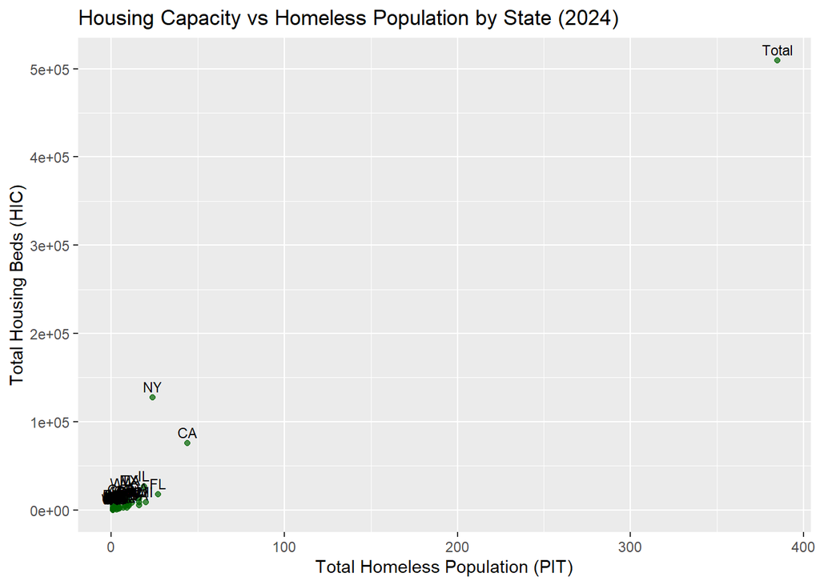

```r
ggplot(hic_pit_2024, aes(x = total_homeless, y = total_beds)) +
geom_point(alpha = 0.7, color = "darkgreen") +
geom_text(aes(label = state), vjust = -0.5, size = 3) +
labs(
title = "Housing Capacity vs Homeless Population by State (2024)",
x = "Total Homeless Population (PIT)",
y = "Total Housing Beds (HIC)"
)
```

# Key Takeaways

Housing capacity is highly concentrated in a small number of states.

Differences in housing types and coverage reflect varying policy approaches across states.

# Next Steps

Future analysis could explore trends over multiple years, assess types of housing vs. need, or examine correlations between unsheltered populations and housing resources.